# Apa itu Data Preparation atau Data Wrangling?

# Apa itu Data Preparation atau Data Wrangling?

> “Data preparation accounts for about 80% of the work of data scientists”

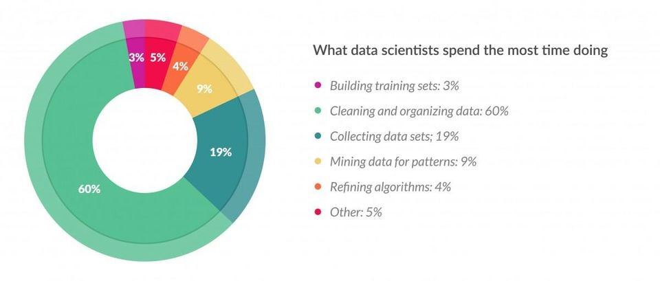

pie chart yang merepresentasikan porsi dari pekerjaan data scientist. Proses data preparation di chart ini adalah Collecting data sets (19%) dan Cleaning and organizing data (60%).

> Data wrangling adalah proses membaca data dari berbagai sumber dan merubah isi dan struktur sehingga dapat digunakan untuk analisa.

## Tiga Tahapan Penting dalam Pengolahan Data

1. Capture Mengumpulkan data mentah
2. Clean Membersihkan & merapikan data
3. Consume Mengkonsumsi hasil visualisasi data yang telah dibersihkan. Biasanya berupa data dashboard.

# Missing Value in R

- Bagaimana missing value direpresentasikan, ini penting sehingga kita bisa identifikasi apakah nilai hilang karena dari awal memang ga ada, apakah karena operasi matematika, dan lain-lain.
- Dengan mengetahui representasi ini, kita dapat melakukan sesuatu terhadapnya. Atau singkat dapat dikelola (manage) dengan baik.

> NA adalah representasi utama dari missing value di R, dan merupakan suatu nilai atomik. Artinya posisi NA sama dengan contoh nilai-nilai atomik bilangan seperti 1, 2 atau 100. Juga sama dengan contoh nilai karakter seperti “a”, “b”, atau “g”. NA tidak bisa digunakan sebagai variable karena merupakan keyword, dan perhatikan penulisan NA dimana kedua karakter adalah huruf besar.

```r
#Ketik nilai NA
NA
```

```
## [1] NA
```

```r
#Tampilkan type dari NA dengan function typeof
typeof(NA)
```

```
## [1] "logical"
```

```r
#Buat variable x yang diisi dengan nilai NA
x <- NA

#Pengecekan variable x dengan nilai NA menggunakan operator ==
x == NA # nolint
```

```
## [1] NA
```

```r
#Pengecekan variable x dengan nilai NA menggunakan function is.na
is.na(x)
```

```
## [1] TRUE
```

```r
typeof(NA_integer_)
```

```
## [1] "integer"
```

```r
typeof(NA_real_)
```

```
## [1] "double"
```

```r
typeof(NA_complex_)
```

```
## [1] "complex"
```

```r
typeof(NA_character_)
```

```
## [1] "character"
```

```r
is.na(NA_integer_)
```

```
## [1] TRUE
```

```r
is.na(NA_real_)
```

```
## [1] TRUE
```

```r
is.na(NA_complex_)
```

```
## [1] TRUE
```

```r
is.na(NA_character_)
```

```
## [1] TRUE
```

```r
#Membuat vector bernama isi.vector dengan isi bilangan, dimana salah satunya memiliki missing value # nolint
isi.vector <- c(1, 2, 3, NA, 3, 1) # nolint

#Mengecek keseluruhan tipe data dengan perulangan lapply dan typeof
lapply(isi.vector, typeof)
```

```
## [[1]]
## [1] "double"
##
## [[2]]
## [1] "double"
##
## [[3]]
## [1] "double"
##
## [[4]]
## [1] "double"
##
## [[5]]
## [1] "double"
##
## [[6]]
## [1] "double"
```

```r
#Menggunakan is.na untuk mengecek keberadaan missing value dari tiap elemen pada vector  # nolint
is.na(isi.vector)
```

```
## [1] FALSE FALSE FALSE  TRUE FALSE FALSE
```

## NULL

Null adalah suatu object khusus di R yang digunakan untuk merepresentasikan nilai atau object yang tidak terdefinisikan.

```r
#Membuat vector dengan 7 elemen termasuk NA dan NULL
isi_vector <- c(1, 2, 3, NA, 5, NULL, 7)
#Menghitung jumlah elemen dari isi.vector
length(isi_vector)
```

```
## [1] 6
```

## Ringkasan Perbandingan NA & NULL

[output not shown]

note: 1. Artinya NA adalah representasi missing value yang “masih” memiliki nilai logika – yang berfungsi sebagai indikator. 2. NULL sendiri adalah objek tidak berbentuk, maka itu tidak terdefinisi dan panjangnya 0. Salah satu operasi yang akan menghasilkan NULL adalah pada saat kita mengakses nama element yang tidak terdapat di dalam suatu list.

```r
#Membuat list dengan 3 elemen termasuk NA dan NULL
isi_list <- list(1, NULL, 3, NA, 5)

#Menghitung jumlah elemen dari isi.list
length(isi_list)
```

```
## [1] 5
```

```r
#Hitung kalkulasi 5 dibagi dengan 0
5 / 0
```

```
## [1] Inf
```

```r
#Hitung kalkulasi -120 dibagi dengan 0
-120 / 0
```

```
## [1] -Inf
```

```r
#Hitung kalkulasi 0 dibagi dengan 0
0 / 0
```

```
## [1] NaN
```

```r
#Hitung logaritma dari angka -1000
log(-1000)
```

```
## [1] NaN
```

```r
#Buat variable contoh.nan
contoh_nan <- 0 / 0

#Periksa dengan function is.nan
is.nan(contoh_nan)
```

```
## [1] TRUE
```

```r
#Masukkan code di bawah ini sesuai permintaan soal
is.na(NaN)
```

```
## [1] TRUE
```

```r
#is.nan(Na) # nolint
```

```r
#Masukkan code di bawah ini sesuai permintaan soal
isi_vector <- c(1, 2, NA, 4, 5, NaN, 6)
sum(is.na(isi_vector) == TRUE)
```

```
## [1] 2
```

## Kesimpulan

- Mengenal representasi missing value di R, yaitu NA (Not Available)
- NA dan variasinya (NA_integer_, NA_real_, NA_complex_, dan NA_character_)
- NULL sebagai representasi missing object
- Perilaku NA dan NULL untuk vector dan list
- NaN sebagai representasi missing value angka (Not a Number)
- Penggunaan function is.na dan is.nan

# Factor

## Pendahuluan

Factor adalah suatu tipe variabel yang intensif digunakan di R

- Apa itu factor dan kenapa diperlukan?
- Kapan factor digunakan
- Cara membuat factor di R
- Bagaimana sebenarnya nilai disimpan di dalam factor
- Menggunakan function untuk merubah nilai factor
- Merubah pengurutan di factor

## Apa itu Factor?

> suatu variable di R yang menyimpan daftar nilai-nilai kategori atau nominal.

contoh daftar nilai kategori yang bisa disimpan dalam factor:

- Nama bulan: Januari, Februari, Maret.
- Jenis pakaian: Atasan, Jeans, Rok, Kaos.
- Satuan berat: kg, mg, ton, kwintal.
- dan lain-lain.

## Kenapa Factor, dan Kapan Sebaiknya Digunakan?

Factor, variabel yang sangat penting untuk digunakan pada kasus analisa statistik, menggambar grafik (plotting), pemodelan regresi ataupun machine learning.

Sebagai contoh kasus, maka fungsi plotting pada library ggplot2 akan mampu mengambil variabel sebagai legend jika direpresentasikan sebagai factor.

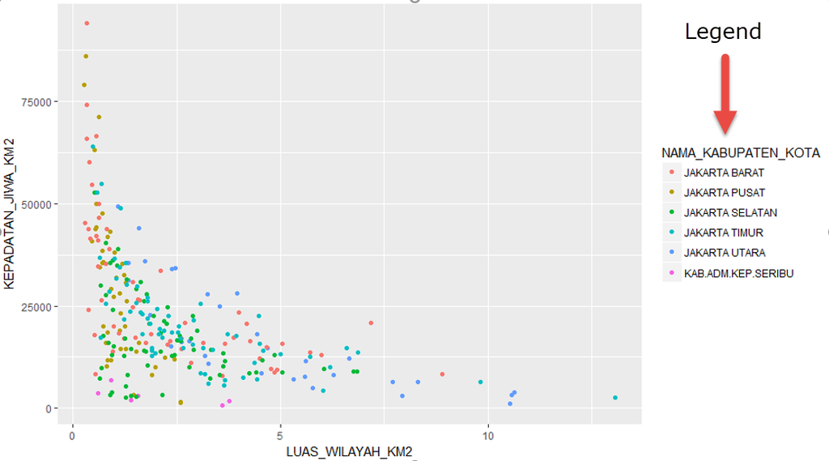

menggunakan factor ketika:

- memastikan bahwa variable yang kita gunakan memiliki data terbatas (diskrit)
- dan menginformasikan kepastian ini kepada function atau model analisa yang kita gunakan

## Kenapa Factor menjadi penting di R?

> Banyak digunakan oleh fungsi analisa dan plotting di R  
> Digunakan oleh ggplot2 untuk legend